# Pstat 105 Lab C

Kendall Brown

Fall 2017

Q1a. Plot of Beta(6,2) CDF vs Grades Empirical CDF

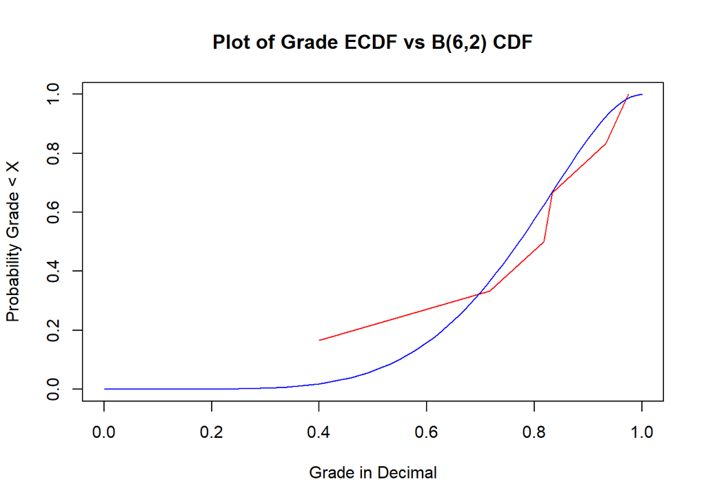

```r
grades=c(40,71.7,81.7,83.3,93.3,97.5)/100
quant=seq(1/6,1,1/6)
plot(grades, quant, type="l",xlim=c(0,1),ylim = c(0,1),xlab="Grade in Decimal",ylab = "Probability Grade < X",main="Plot of Grade ECDF vs B(6,2) CDF",col="red")
curve(pbeta(x,6,2),add=T,col="blue")
```

Q1b.Plot of Gn(t)

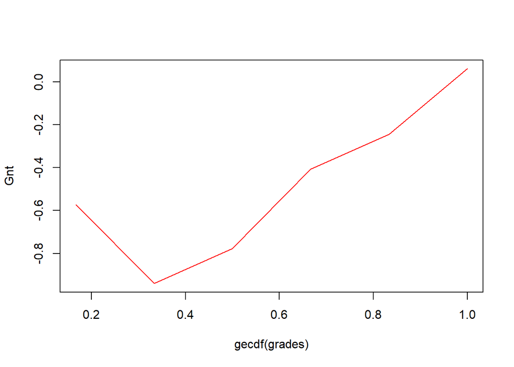

```r
gecdf=ecdf(grades)
Gnt=(sqrt(6))*(gecdf(grades)-grades)
plot(gecdf(grades),Gnt,col="red",type="l")
```

Q1c.Ks test for beta distribution of grades.

```r
ks.test(grades,"pbeta",6,2)
```

```
##
##  One-sample Kolmogorov-Smirnov test
##
## data:  grades
## D = 0.2906, p-value = 0.5955
## alternative hypothesis: two-sided
```

```r
#Taking 0<U1<U2<U3<...<U6<1
#from the D statistic D=.2906, D+=max(1-U6,5/6-U5,2/3-U4,1/2-U3,1/3-U2,1/6-U1) or D-=max(U1,U2-1/6,U3-1/3,U4-1/2,U5-2/3,U6-5/6)
#since 0<Ui<1, D+ implies that if U6<.7094 then Ui<.7094, similarly if U1>.2906 then Ui>.2906
#From this we can calculate the exact P-value
epv=(.7094^5)+(.7094)^5
epv #Exact P-value
```

```
## [1] 0.3593237
```

Q1d.From this P-value we fail to reject the null hypothesis, there is not enough evidence to suggest the data does not follow B(6,2).

Q1e. It would be difficult to preform a chi-squared test here because we have very few samples to distribute enough amongst bins to calculate the X2 test statistic.

Q2a.Histogram and Normal Curve of Shoulder Data

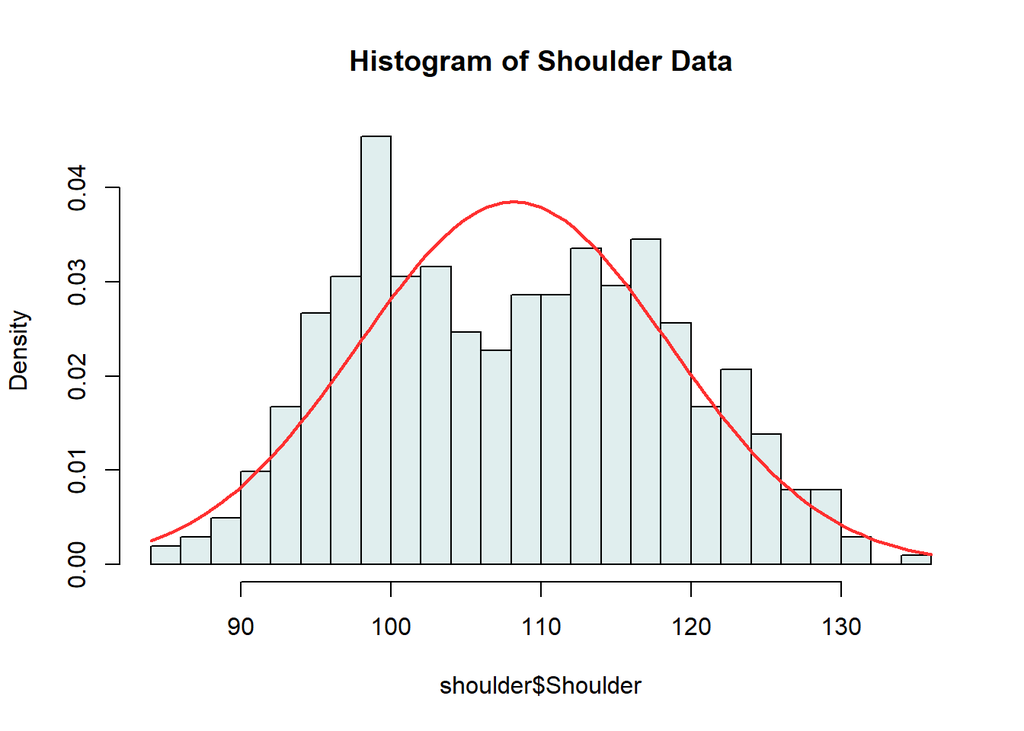

```r
shoulder=read.table("C:/Users/kebro/Desktop/PSTAT 105/shoulder.txt",header = TRUE)
hist(shoulder$Shoulder,main="Histogram of Shoulder Data",breaks = 25,probability = TRUE,col="azure2")
ssd=sd(shoulder$Shoulder)
sm=mean(shoulder$Shoulder)
curve(dnorm(x,mean=sm,sd=ssd),add = TRUE,col="firebrick1",lw=2)
```

Q2b.Tests of Shoulder Data

```r
#lillie.test(shoulder$Shoulder)
#cvm.test(shoulder$Shoulder)
#ad.test(shoulder$Shoulder)
```

Q2c.Tests of Shoulder Data by Gender

```r
mshoulder=subset(shoulder,Gender=="Male")
fshoulder=subset(shoulder,Gender=="Female")
#Male Shoulders
#lillie.test(mshoulder$Shoulder)
#cvm.test(mshoulder$Shoulder)
#ad.test(mshoulder$Shoulder)
#Female Shoulders
#lillie.test(fshoulder$Shoulder)
#cvm.test(fshoulder$Shoulder)
#ad.test(fshoulder$Shoulder)
```

Q2d. Normaility Tests for Adjusted Shoulder Width

```r
amshoulder=mshoulder$Shoulder-mean(mshoulder$Shoulder)
afshoulder=fshoulder$Shoulder-mean(fshoulder$Shoulder)
ashoulder=c(amshoulder,afshoulder)
#lillie.test(ashoulder)
#cvm.test(ashoulder)
#ad.test(ashoulder)
```

```r
EarthquakeData <- read.csv("C:\\Users\\kebro\\Desktop\\PSTAT 105\\EarthquakeData.htm", header = TRUE, skip = 13, nrows=1826,colClasse=c("integer", "integer","integer", "character","numeric","numeric","numeric","integer","factor"))
eq.hour <- as.integer(substr(EarthquakeData$Time,1,2))
eq.min <- as.integer(substr(EarthquakeData$Time,3,4))
eq.sec <- as.numeric(substr(EarthquakeData$Time,5,8))
```

Q3a. Chi-Squared Test for Uniformity Across Hours of Day.

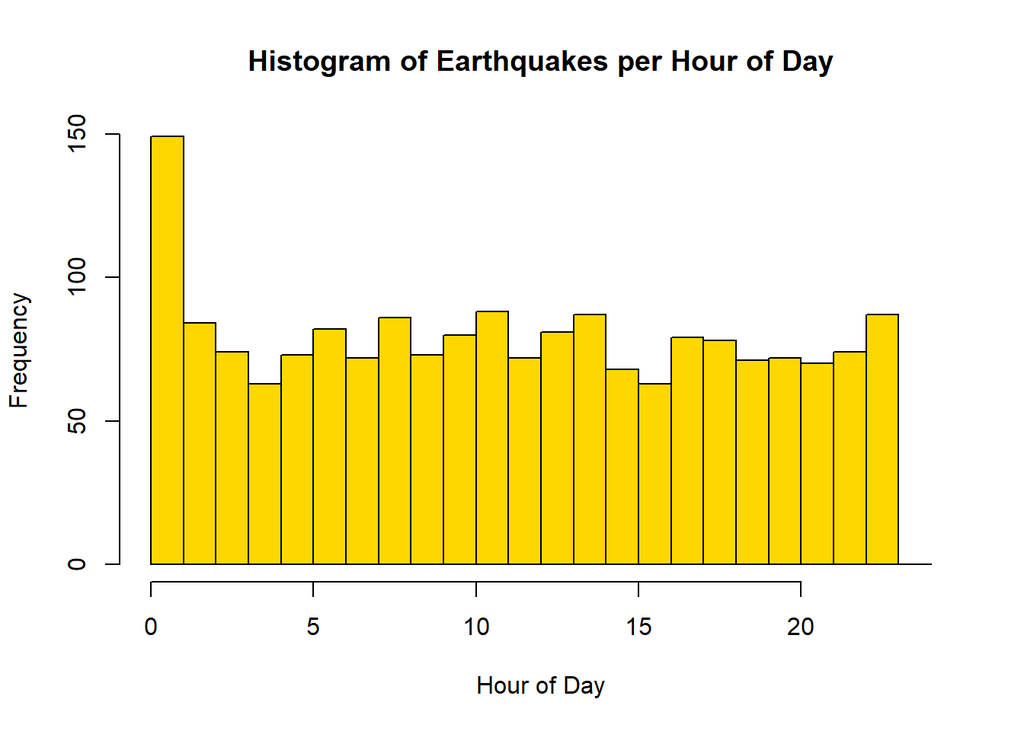

```r
pph=rep((1/24),24)
disteqh=(hist(eq.hour,breaks = seq(0,24,1),xlab="Hour of Day", main="Histogram of Earthquakes per Hour of Day",col="gold1"))
```

```r
chisq.test(disteqh$counts,p=pph)
```

```
##
##  Chi-squared test for given probabilities
##
## data:  disteqh$counts
## X-squared = 161.43, df = 23, p-value < 2.2e-16
```

Q3b. KS-Test of Hourly Data.

```r
eq.time=(3600*eq.hour)+(60*eq.min)+eq.sec #Converting time of day to seconds past midnight.
ecdfeq=sort(eq.time)/86400 #With 86400 secs/day we can get the ecdf of the time data.
ecdfuni=seq(0,1,length=1826) #Uniform CDF of seconds past in a day with 1826 intervals
Dp=(ecdfuni-ecdfeq)
Dm=(ecdfeq-ecdfuni)
max(Dp) #Dplus value
```

```
## [1] 0.01319614
```

```r
max(Dm) #Dminus value
```

```
## [1] 0.01251513
```

```r
Dmax=max(max(Dp),max(Dm)) #D test statistic
```

Q3c. P-value of KS.Test

```r
n=c(1,2,3,4,5,6,7,8,9,10)
pv=2*sum(((-1)^(n-1))*exp(-2*1826*(n^2)*(Dmax^2)))#Approximating P-Value with 10 sums.
pv#Approximated p-Value given D statistic
```

```
## [1] 0.908189
```

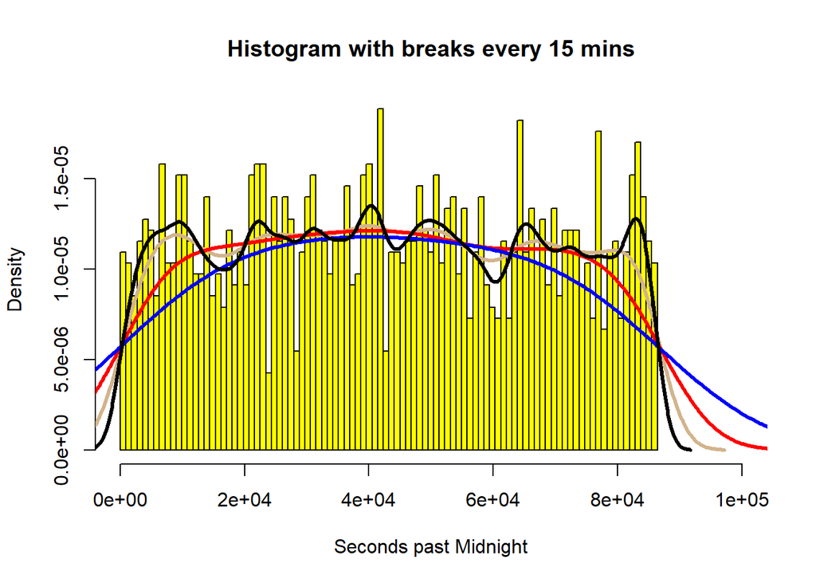

```r
hist(eq.time,breaks = seq(0,86400,900),main="Histogram with breaks every 15 mins",xlab="Seconds past Midnight",xlim=c(0,100000),probability = TRUE,col=135)
lines(density(eq.time,bw=3600,kernel="gaussian"),col="tan",lw=3) #BW is an hour
lines(density(eq.time,bw=3600*2,kernel="gaussian"),col="red",lw=3) #BW is two hours
lines(density(eq.time,bw=3600*4,kernel="gaussian"),col="blue",lw=3) #BW is four hours
lines(density(eq.time,bw=3600/2,kernel="gaussian"),col="black",lw=3) #BW is 30 mins
```

I belive that the 2 and 4 hour bandwidths gave kernels that were too smooth. As such I believe the 1 hour bandwidth to be bettwe than both the 2 and 4 hour bandwidths, but not as good as the 30 min bandwidth which. It is a bit rough but it matches the underlying histogram a bit better. Q3f.

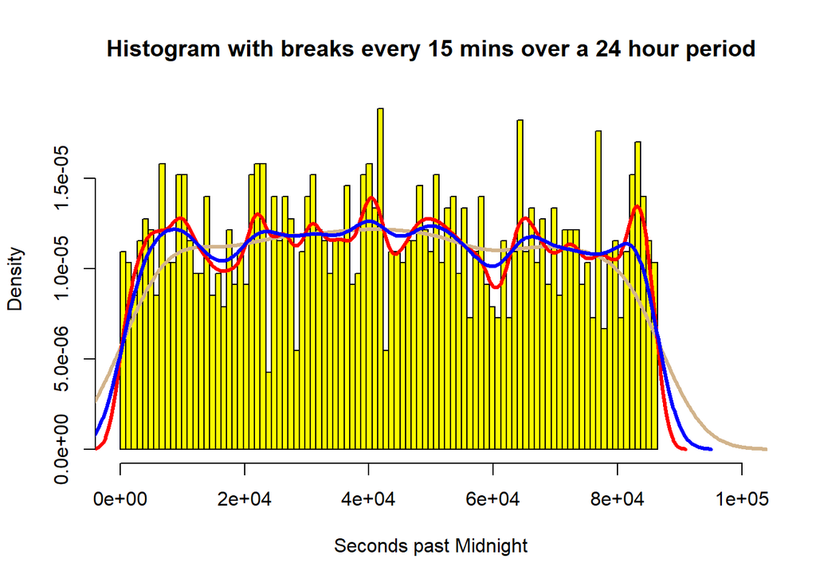

```r
hist(eq.time,breaks = seq(0,86400,900),main="Histogram with breaks every 15 mins over a 24 hour period",xlab="Seconds past Midnight",xlim=c(0,100000),probability = TRUE,col=135)
lines(density(eq.time,bw="nrd",kernel="gaussian"),col="tan",lw=3) #BW is the nrd
lines(density(eq.time,bw="ucv",kernel="gaussian"),col="red",lw=3) #BW is the ucv
lines(density(eq.time,bw="SJ",kernel="gaussian"),col="blue",lw=3) #BW is the SJ
```

I would say that the UCV bandwidth method is the most accurate bandwidth of NRD, UCV, and SJ as it appears to match the histogram’s distribution well.

Q3g.Fixing cyclical data.

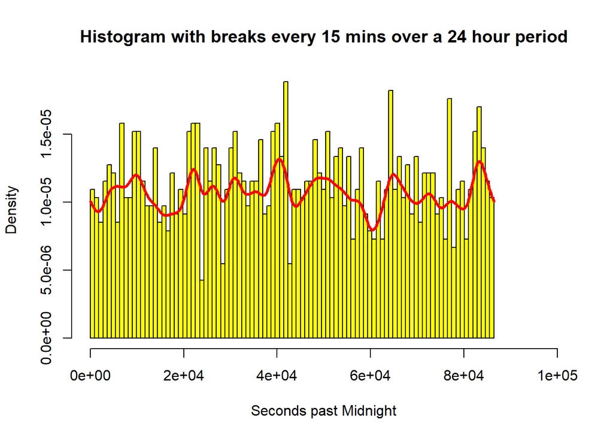

```r
seq.time=sort(eq.time)
histeq=hist(eq.time,breaks = seq(0,86400,900),main="Histogram with breaks every 15 mins over a 24 hour period",xlab="Seconds past Midnight",xlim=c(0,100000),probability = TRUE,col=135)
deneq=density(c(eq.time,seq.time[1739:1826]-86400,seq.time[0:68]+86400),bw="ucv",kernel="gaussian",from=0, to=86400)
#Took the first's and last's hour of datapoints and affixed them to the ends of the set used them to approximate
#the density at hour 0 and hour 24.
lines(deneq,col="red",lw=3)
```

```r
snow <- scan("snow.txt")
```

Q4a.Histogram of Snow.txt

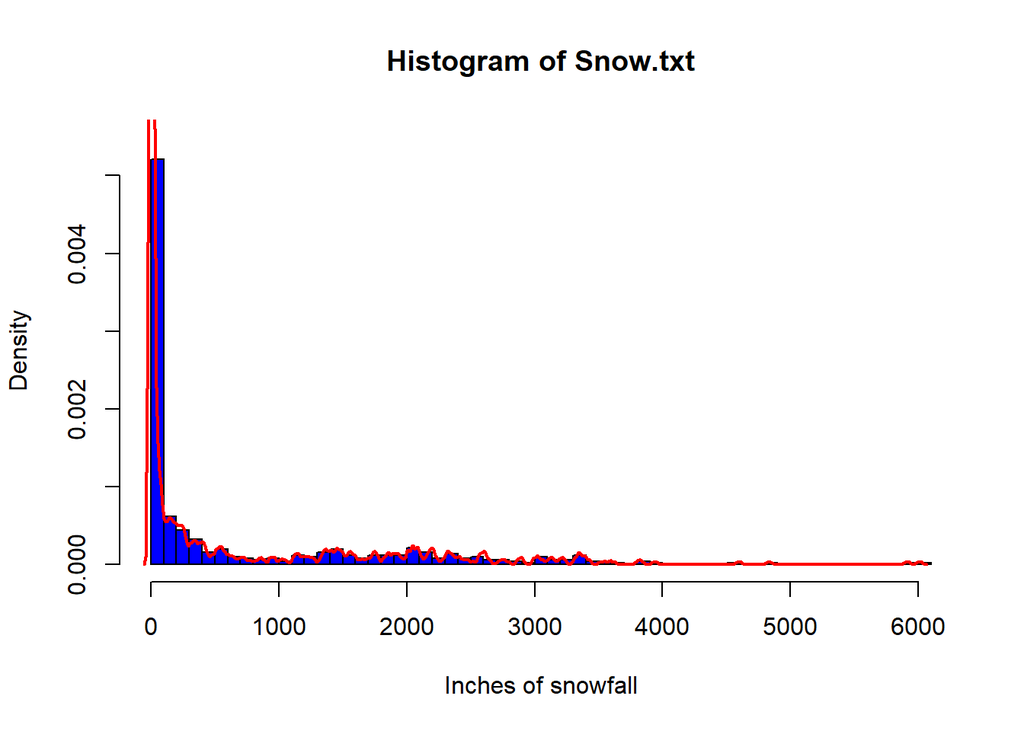

```r
hists=hist(snow,breaks=50,main="Histogram of Snow.txt",col="blue",probability = T,xlab="Inches of snowfall",ylim = c(0,.0055))
dsnow=density(snow,bw="SJ",kernel="rectangular")
lines(dsnow,lw=2,col="red")
```

Q4b.Estimation at 2000

```r
c2000=sum(hists$counts[20:22])
c2000
```

```
## [1] 25
```

```r
density(snow,bw="SJ",kernel="rectangular",from=1900,to=2100)
```

```
##
## Call:
##  density.default(x = snow, bw = "SJ", kernel = "rectangular",     from = 1900, to = 2100)
##
## Data: snow (499 obs.);   Bandwidth 'bw' = 18.62
##
##        x              y
##  Min.   :1900   Min.   :3.108e-05
##  1st Qu.:1950   1st Qu.:1.243e-04
##  Median :2000   Median :1.865e-04
##  Mean   :2000   Mean   :1.686e-04
##  3rd Qu.:2050   3rd Qu.:2.175e-04
##  Max.   :2100   Max.   :3.108e-04
```

```r
c2100=sum(hists$counts[1:22])
c1900=sum(hists$counts[1:20])
Fht=(c2100-c1900)/499/(2*18.62)
sv=.0001686/(2*499*(18.62^2))
d2000=.0001686
cint=c(d2000-1.96*sqrt(sv/499),d2000+1.96*sqrt(sv/499))
cint
```

```
## [1] 0.0001666632 0.0001705368
```

With a bandwidth of 18.62 and a rectangular Kernel, we have a sample density of .0001686 based off of 25 observations. 95% confidence interval {0.0001666632, 0.0001705368}

Q4c. Prob of snowfall in a year

```r
sort(snow)[183]
```

```
## [1] 0
```

```r
psnow=183/499
psnow #Probability a station sees a warm winter
```

```
## [1] 0.3667335
```

Q4d. Density where snow!=0.

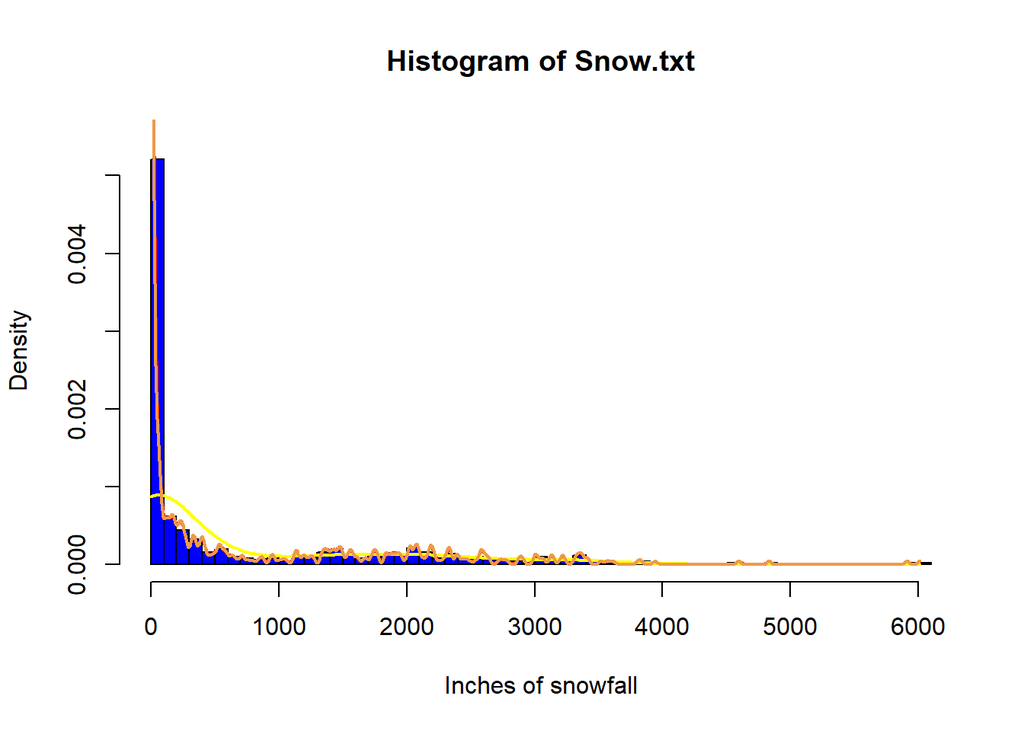

```r
hists=hist(snow,breaks=50,main="Histogram of Snow.txt",col="blue",probability = T,xlab="Inches of snowfall",ylim = c(0,.0055))
lines(density(snow,bw="SJ",kernel="gaussian",from=1,to=6009),lw=2,col="red")
lines(density(snow,bw="nrd",kernel="gaussian",from=1,to=6009),lw=2,col="yellow")
lines(density(snow,bw=15,kernel="gaussian",from=1,to=6009),lw=2,col="tan2")
```

The 15 bandwidth looks nice. Density for snow>0 is approximately 1.4*10^-4

Q4e.As a guess I would say that the bias of the estimate is rather significant as the data is quite obviously skewed towards lower values.